# Full Environmental Predictor Analyses

Prepared by Joey Hulbert, Washington State University

June, 2022 (in progress)

| [Home](https://jmhulbert.github.io/redcedar) | [Data Wrangling](https://jmhulbert.github.io/redcedar/data-wrangle/) | [Data Analyses](https://jmhulbert.github.io/redcedar/analyses/) | [Data Visualization](https://jmhulbert.github.io/redcedar/data-visualization/) |
| --- | --- | --- | --- |

# Purpose

# Approach

# Data

## iNat

## Soils

## Climate

## Topo

## Combined

# Data Wrangle

```
## # A tibble: 12 × 2
## # Groups:   field.tree.canopy.symptoms [12]
##    field.tree.canopy.symptoms                             n
##    <fct>                                              <int>
##  1 Branch Dieback or 'Flagging'                          74
##  2 Browning Canopy                                       43
##  3 Candelabra top or very old spike top (old growth)      2
##  4 Extra Cone Crop                                        4
##  5 Healthy                                              813
##  6 Multiple Symptoms (please list in Notes)              31
##  7 New Dead Top (red or brown needles still attached)    48
##  8 Old Dead Top (needles already gone)                  154
##  9 Other (please describe in Notes)                      16
## 10 Thinning Canopy                                      225
## 11 Tree is dead                                          74
## 12 Yellowing Canopy                                      26
```

## Filter data

### Filter observatoins

We also want to filter observations to only those within Oregon and Washington as those are the only observations we extracted TOPO data for.

## Remove unwanted predictors

### iNat variables

- Note the following fields were removed because they’re not explanatory variables for the below model
  - “field.optional…were.there.any.other.unhealthy.plant.species.on.the.site.”
  - “field.optional…timing.of.symptoms.estimate”
  - “field.optional…estimated.time.spent.to.make.this.observation….of.minutes.”
  - “field.optional…can.we.follow.up.with.you.”
  - “field.percent.canopy.affected….”
  - “field.number.of.additional.unhealthy.trees..of.same.species..in.area..within.sight.”
  - “field.percent.of.trees..of.same.species..within.sight.that.are.unhealthy”
  - “field.notes”
  - field.optional…what..other.factors..were.observed.
    - note this may be an important predictor, but the data is likely baised because users were only likely to report other factors on unhealthy trees.

### Soil variables

Then, remove specific soils variables not useful as explanatory variables (e.g. MUKEY)

#### Removed from muaggatt

#### Removed from component

#### Removed from coecoclass

We kept “coecoclass_ecoclassname” and “coecoclass_ecoclasstypename”

#### Removed from valu1

### Climate variables

Then, remove specific climate variables not useful as explanatory variables (e.g. norm_Latitutde)

## Filter near zero standard deviations

Remove variables with variables that have near zero standard deviations (entire column is same value)

## (Optional?) Remove variables with missing data

We can also remove columns without any data (entire column is NAs)

Then check number of NAs per remaining column

- The below variables are examples of those without much data (column contains mostly NAs)
  - component_rsprod_h
  - component_rsprod_l
  - component_rsprod_r
  - component_totalsub_h
  - component_totalsub_l
  - component_totalsub_r
  - component_reannualprecip_r
  - component_reannualprecip_l
  - component_reannualprecip_h

## Group response variables to binary values

Binary tree health categories

```
## # A tibble: 2 × 2
## # Groups:   field.tree.canopy.symptoms [2]
##   field.tree.canopy.symptoms     n
##   <fct>                      <int>
## 1 Healthy                      607
## 2 Unhealthy                    542
```

## Normal, Monthless Model

## Impute data

We continue to get the below error, but were able to work around it by imputing the data.

> Error in randomForest.default(m, y, …) : Need at least two classes to do classification.

To impute the data we have to remove factors with >53 levels. For example, ‘component_taxclnam’ has 132 levels

- The following factors had more than 53 levels
  - “muaggatt_musym”
  - “muaggatt_muname”
  - “component_compname”
  - “component_geomdesc”
  - “component_taxclname”
  - “component_taxsubgrp”
  - “component_taxgrtgroup”
  - “coecoclass_ecoclassname”

Imputed data table

```
## ntree      OOB      1      2
##   300:  31.59% 30.31% 33.03%
## ntree      OOB      1      2
##   300:  31.51% 28.83% 34.50%
## ntree      OOB      1      2
##   300:  31.51% 31.14% 31.92%
## ntree      OOB      1      2
##   300:  31.33% 29.32% 33.58%
## ntree      OOB      1      2
##   300:  30.46% 29.65% 31.37%
## ntree      OOB      1      2
##   300:  32.64% 31.63% 33.76%
```

# Approach

- General approach
  - build full model using binary response grouping variable and climate response variable (see climate data analysis)
    - binary response
  - refine model to remove redundant explanatory variables
    - use refined (normal, monthless model to test whole dataset)

# Models

- Random forest model criteria
  - nearzero variation columns were removed
  - (optional, not applied but should be considered) columns with missing data [more than 80%?] should be removed?
  - Data were imputed prior to model building (full and soils analyses only).
  - number of splits was not defined to allow automatic selection,
  - ntree = 2001, importance = TRUE, proximity = TRUE, na.action = na.omit
  - seed was set for reproducability with: set.seed(71)

```
##
## Call:
##  randomForest(formula = field.tree.canopy.symptoms ~ ., data = data.imputed,      ntree = 2001, importance = TRUE, proximity = TRUE, na.action = na.omit)
##                Type of random forest: classification
##                      Number of trees: 2001
## No. of variables tried at each split: 15
##
##         OOB estimate of  error rate: 31.07%
## Confusion matrix:
##           Healthy Unhealthy class.error
## Healthy       434       173   0.2850082
## Unhealthy     184       358   0.3394834
```

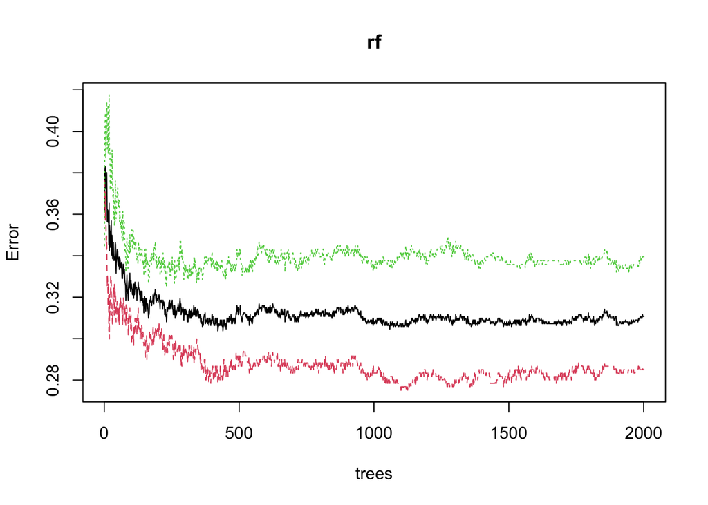

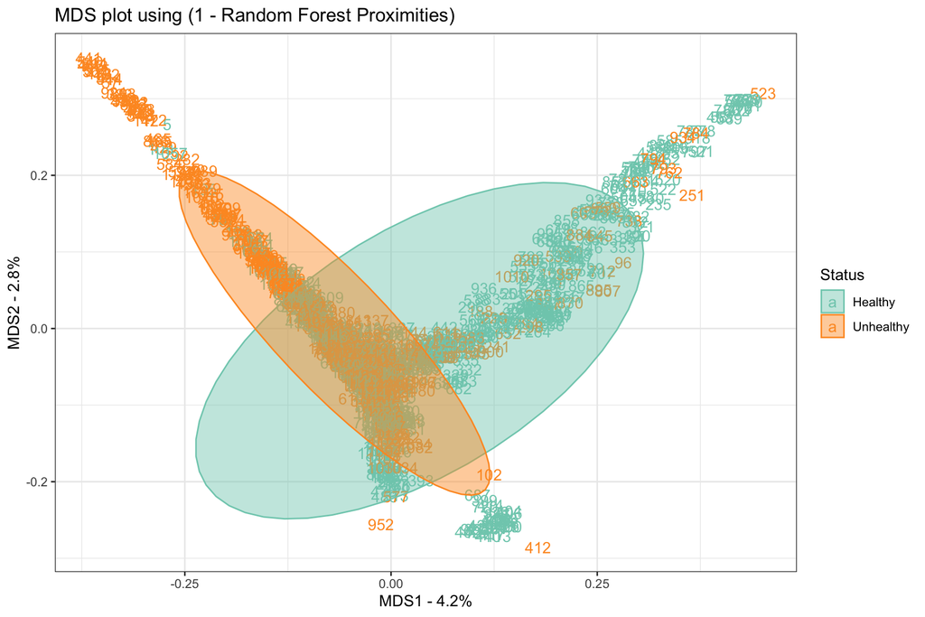

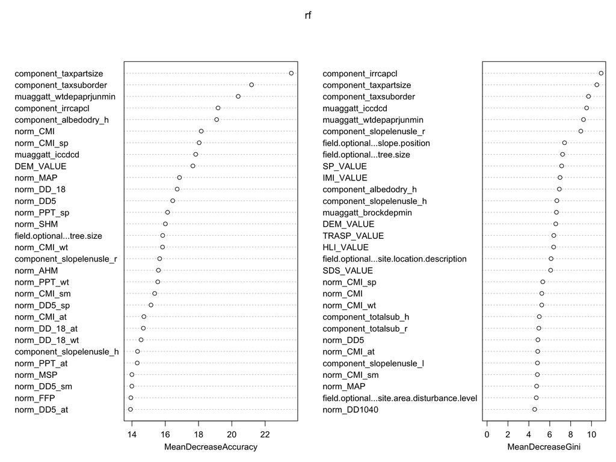